# hw02

Мухтаров Андрей

26 ноября 2016 г

## Домашнее задание № 2

Загрузка и очистка данных

```r
data<-read.csv("https://raw.githubusercontent.com/SergeyMirvoda/da2016/master/data/calif_penn_2011.csv")
#11275 * 34
```

Bыполните следующую команду и объясните, что она делает. colSums(apply(data,c(1,2), is.na))

```r
colSums(apply(data,c(1,2), is.na))
```

```
##                           X                     GEO.id2
##                           0                           0
##                     STATEFP                    COUNTYFP
##                           0                           0
##                     TRACTCE                  POPULATION
##                           0                           0
##                    LATITUDE                   LONGITUDE
##                           0                           0
##           GEO.display.label          Median_house_value
##                           0                         599
##                 Total_units                Vacant_units
##                           0                           0
##                Median_rooms  Mean_household_size_owners
##                         157                         215
## Mean_household_size_renters         Built_2005_or_later
##                         152                          98
##          Built_2000_to_2004                 Built_1990s
##                          98                          98
##                 Built_1980s                 Built_1970s
##                          98                          98
##                 Built_1960s                 Built_1950s
##                          98                          98
##                 Built_1940s       Built_1939_or_earlier
##                          98                          98
##                  Bedrooms_0                  Bedrooms_1
##                          98                          98
##                  Bedrooms_2                  Bedrooms_3
##                          98                          98
##                  Bedrooms_4          Bedrooms_5_or_more
##                          98                          98
##                      Owners                     Renters
##                         100                         100
##     Median_household_income       Mean_household_income
##                         115                         126
```

```r
#Суммирует колонки, где есть пропущенные данные
```

Функция na.omit() принимает датафрейм и возвращает новый датафрейм, игнорируя строки, содержащие значение NA. Используйте эту функцию для удаления строк с неполными данными.

```r
data2<-na.omit(data)
nrow(data)-nrow(data2)
```

```
## [1] 670
```

```r
# не соответствует п3 так как na повторяется в строках
```

## Новые дома

Переменная(колонка) Built_2005_or_later содержит данные о проценте домов, построенных с 2005 года. Постройте диаграмму рассеяния (scatterplot) медианы стоимости домов (переменная Median_house_value) относительно процента новых домов.

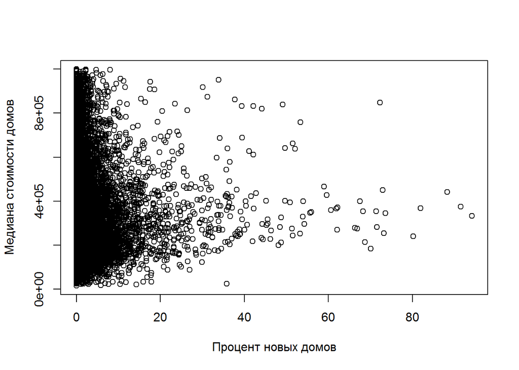

```r
plot(data2$Built_2005_or_later, data2$Median_house_value, xlab = "Процент новых домов", ylab = "Медиана стоимости домов")
```

Постройте ещё два графика для каждого из штатов отдельно. Номер штата содержится в переменной (STATEFP), где Калифорния 6-й штат, а Пенсильвания 42.

[figure not shown]

```r
C1<-data2$Built_2005_or_later[data2$STATEFP==6]
C2<-data2$Median_house_value[data2$STATEFP==6]
plot(C1,C2,main="Калифорния", xlab="Median_house_value", ylab="Built_2005_or_later")
```

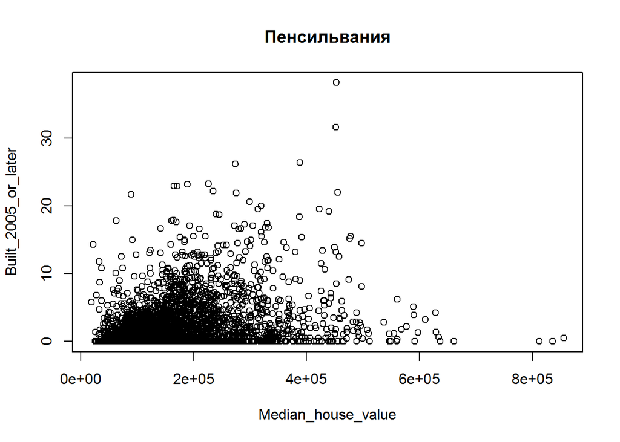

```r
C1<-data2$Built_2005_or_later[data2$STATEFP==42]
C2<-data2$Median_house_value[data2$STATEFP==42]
plot(C2,C1,main="Пенсильвания", xlab="Median_house_value", ylab="Built_2005_or_later")
```